# PROJECT TITLE: RELATIONSHIP BETWEEN SOCIAL STATUS AND BIKE RIDING SPORT

# INVESTIGATION OVERVIEW

This notebook looks into using python-based analytics and data wrangling in an attempt to get insights on the data gotten from ford Gobike system data.

In this investigation, i wanted to look at how social status like age group, sex, day and social app affects the bike riding sport and if bike riding is more perculiar to some social groups or less perculiar to other social group

# DATASET OVERVIEW

The data consists of sixteen columns which includes Age, Gender, Start time, Duration seconds amongst others. It contains 183,412 rows. After excessive wrangling and Feature engineering, extra three columns were added and a total of 8652 rows was removed due to incorrect and incomplete data

# DISTRIBUTION OF GENDERS OF USERS

Gender of users was visualized on a barchart so as to easily show how gender that rode bikes in a simple form. I observed that Male have the highest ratio of cyclist

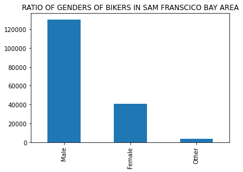

# Users Of Ford Gobike System

The ratio of Users of ford gobike system was visualized on a bar chat and it was discovered that users majorly comprises of Suscribers and customers but Suscribers made up of over 70% of bikers ecosystem in San Fransisco Bay area

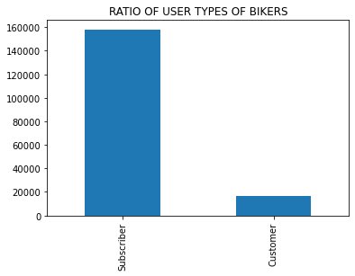

# Age group of bike riders

The age group of bike riders in this dataset was plotted on a bar chat.I discovered that the age grop between 29-31 has the largest distribution and 65 - 80 has the lowest distribution of bikers. this depicts that the older an individual grow, the less likely they will ride bike

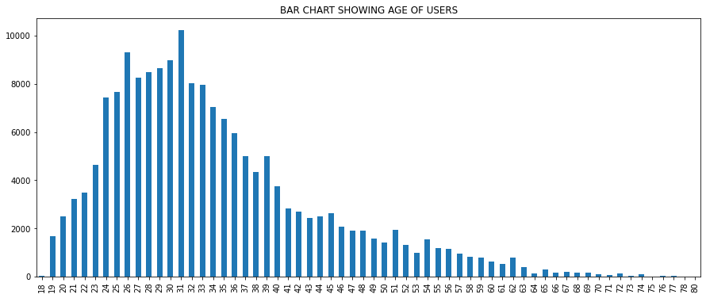

# Relationship between duration seconds and member age

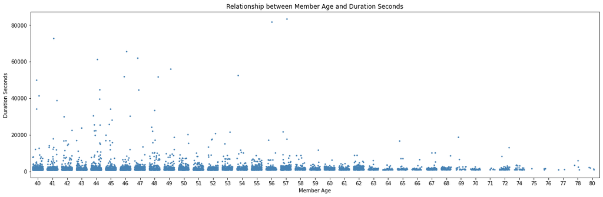

# Relationship between gender of and duration seconds

This relationship was plotted on a violin plot so as to get the distribution of the plots. I found out that female has the highest range of duration seconds while Male has the largest distribution of Duration seconds and that duration seconds is not dependent on gender as i thought it would be

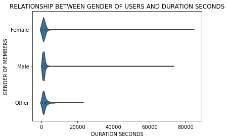

# Relationship between member age, duration seconds and member_gender

This relationship was plotted on a scatter plot so as to get the distribution of the plots. I found out that Male has the largest distribution of data, Female has the highest distribution of data and Bikers that are between the age of 29-31 have higher duration seconds as compared to bikers of other age group

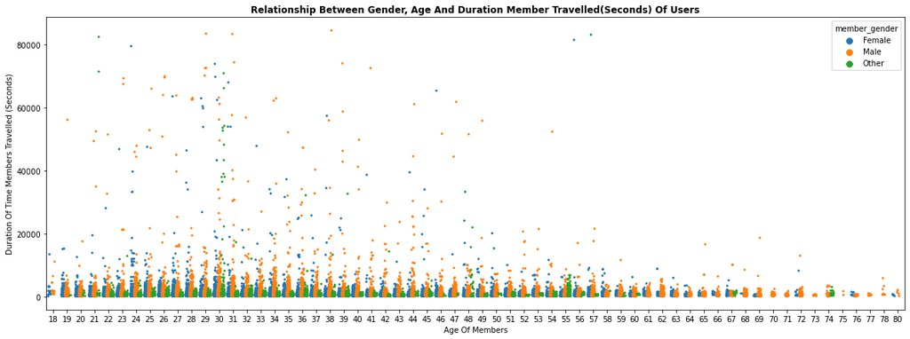

# What part of the day do bikers ride the most?

The parts of day that riders rides the most in this dataset was plotted on a bar chat.I discovered that bikers ride most in the morning and this could be as a result of the mild weather

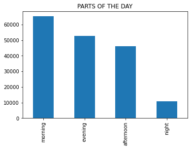

# Relationship between how long a biker travelled and when they travelled

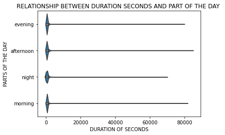

# SUMMARY